# Phylogenetic Analysis

MOL.923 Computerlabor Bioinformatik (WS 2024/25)

08/01/2025

## Alignments und phylogenetische Bäume mit Webtools erstellen

Erzeugen Sie ein MSA von den Dateien *TTR_clean.fas* und *RAG2_clean.fas* mit *clustalOmega*, *mafft* oder *muscle5* (https://www.ebi.ac.uk/jdispatcher/msa).

- Betrachten Sie die Alignmente? Gibt es potientielle Probleme? Welche?

Benutzen Sie die Datei *concatenated_dna.fasta* um einen phylogenetischen Baum zu berechenen (http://iqtree.cibiv.univie.ac.at/). Benutzen Sie die Standardeinstellungen.

- Welches Model wurde verwendet?
- Sind die unterschiedlichen Familien (Katzen, Hunde, Bären, etc.) monophyletic?
- Sie können die Bäume mit (https://itol.embl.de/) anschauen!

## Bäume und Alignments in R visualisieren

An den Computern im Übungsraum ist R / RStudio und die Pakete die wir benutzen schon installiert. Hier wollen wir kurz zeigen welche Möglichkeiten Skripten bieten.

Öffnen Sie RStudio auf den Lab-Computern und kopieren Sie den folgenden Code in die Konsole (Console). Zuerst laden wir zwei Packete die Phylogonien erstellen und bearbeiten.

```r
library(ape)
library(phangorn)
```

Danach laden wir 3 Datensätze, einen phylogenetischen Baum, ein Alignment und eine Tabelle mit Information zu unseren Daten.

```r
tree_file <- "https://raw.githubusercontent.com/KlausVigo/Mol504/refs/heads/main/iqtree/concatenated_dna.fasta.treefile"
align_file <- "https://raw.githubusercontent.com/KlausVigo/Mol504/refs/heads/main/data/concatenated_dna.fasta"
tab_file <- "https://raw.githubusercontent.com/KlausVigo/Mol504/refs/heads/main/data/cats_dogs.csv"

tree <-  read.tree(tree_file)
align <- read.phyDat(align_file, format="fasta")
tab <- read.csv(tab_file)
```

Wir können das ganze Alignment oder nur einen Ausschnitt visualisieren und wenn wir wollen als pdf oder einem anderen Fromat speichern.

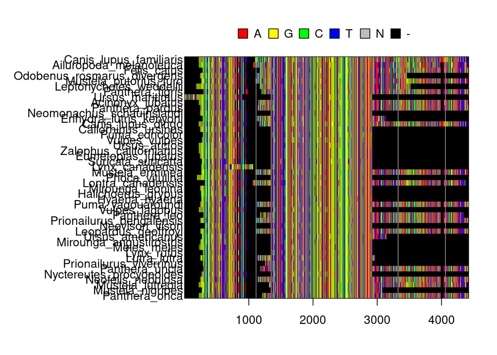

```r
par(mar=c(4,13,4,2))
image(align)
```

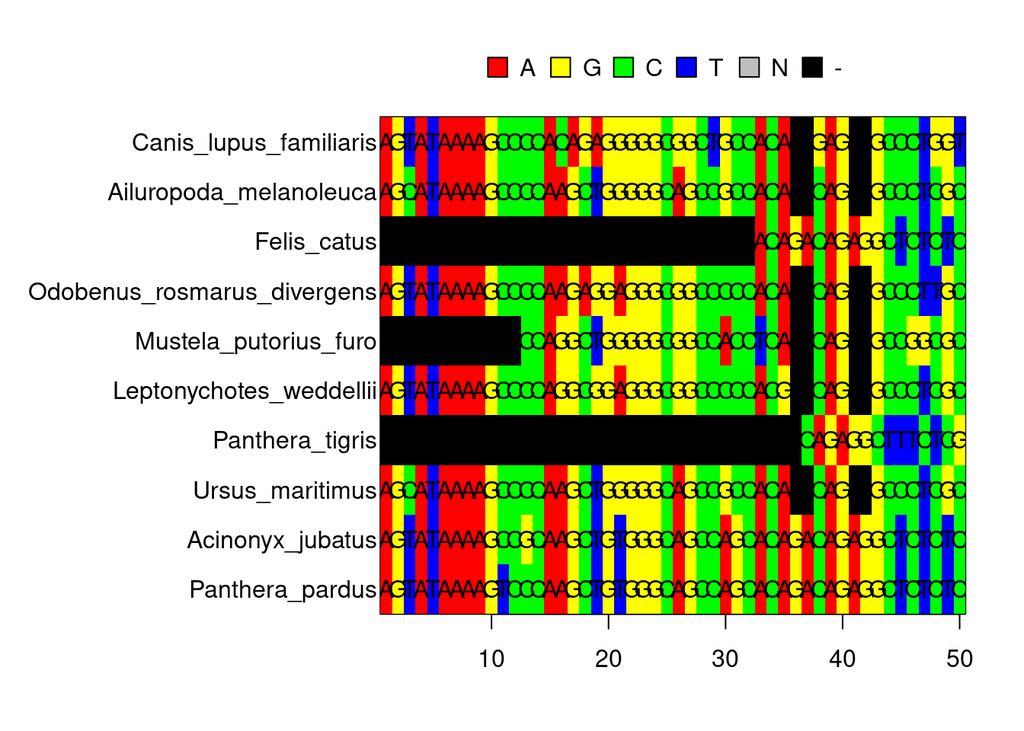

```r
image(align[1:10, 251:300], show.bases=TRUE)
```

Wir können auch phylogenetische Bäume malen und haben dafür eine Menge Optionen.

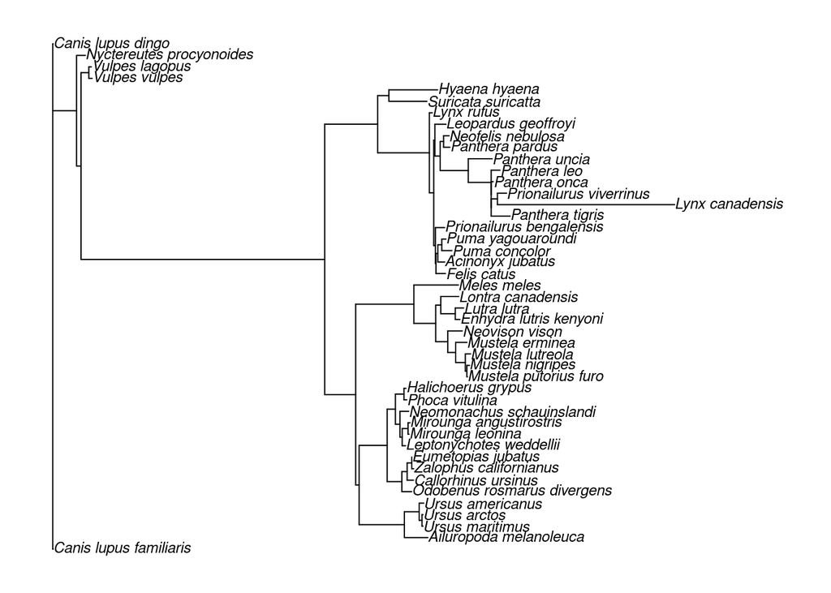

```r
par(mar=c(1,1,1,1))
plot(tree, cex=.75)
```

Jetzt verwenden wir ein paar Farben um die unterschiedlichen Familien besser zu erkennen.

```r
par(mar=c(1,1,1,1))
col <- c("green", "blue", "lightblue", "red", "orange", "brown", "yellow",
         "darkgreen", "magenta")
family_color <- setNames(col, unique(tab$Family))
family_color
```

```
##     Felidae     Ursidae   Otariidae     Canidae  Mustelidae    Phocidae
##     "green"      "blue" "lightblue"       "red"    "orange"     "brown"
##   Hyaenidae  Odobenidae Herpestidae
##    "yellow" "darkgreen"   "magenta"
```

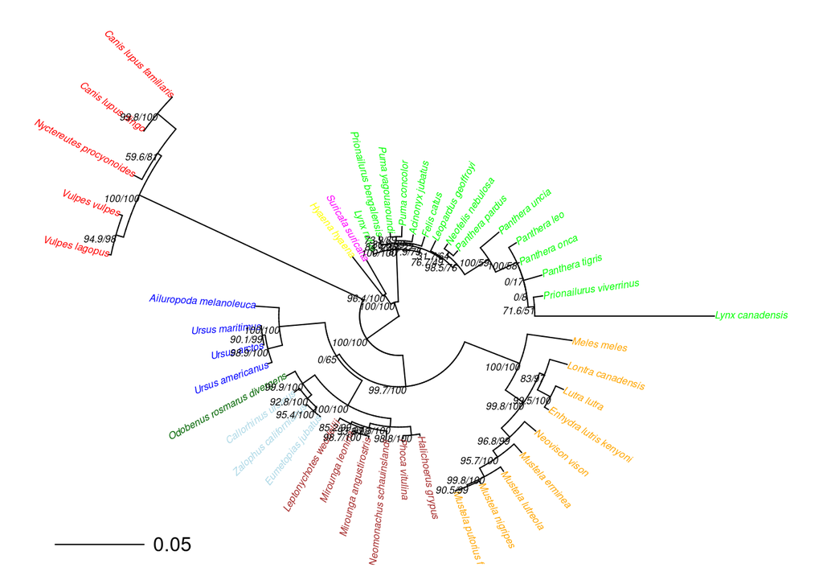

```r
tip_color <- setNames(family_color[tab$Family], tab$Species)


tree <- midpoint(tree)

plot(tree, type="fan", tip.col=tip_color[tree$tip.label], cex=.5, show.node.label = TRUE)
add.scale.bar()
```

Die Funtion *plot.phylo*, wir können aber nur *plot* schreiben, hat viele Optionen

```r
help(plot.phylo)
```

Wir können die Species “Lynx_canadensis” von dem Baum löschen, da es scheinbar mit der Sequenz Probleme gibt. Wie sieht der Baum jetzt aus?

```r
tree2 <- drop.tip(tree, "Lynx_canadensis")
tree <- midpoint(tree2)
plot(tree, cex=.75)
plot(tree, type="fan", tip.col=tip_color[tree$tip.label], cex=.5, show.node.label = TRUE)
```

[output not shown]